# Bike sharing a feasible scheme or not?

## by (Chigozie Chukwu)

## Overview

The bikeshare data, as I named the data got us some interesting insights. During the unvariant exploration I found out that, there were more subscribers to the bike sharing scheme than there are customers and the proportion of members that used the bike sharing scheme for all trips were not up to half of those that did not use it. Males used the bike more than the female and other genders. The charts also indicates that there was an initial success in the bike sharing scheme and the younger generations utilized the bike sharing scheme more than the older adults. The members did covered smaller distance with the bike and rarely used it for all trips.

Going on the bivariant exploration, I found out that the total members were more of males and most of them were subcribers to the scheme. Although, most of them did not use the bike in the sharing scheme for all their trips, they all covered a smilar distances with the bike. Those of younger age group spent more time(in seconds) riding the bike than those of older generation.

Wow, the bike sharing scheme was actually a success and the new generations should be considered while manufacturing the bike used in the scheme as, more of them were involved than the older generations.

## Dataset Overview

The Ford GoBike System dataset includes information about individual rides made in a bike-sharing system covering the greater San Francisco Bay area. it has 16 columns including duration_sec; this is the time interval each user rides the bike from one point to another, start_time, end_time, start_station_id, start_station_name, start_station_latitude, start_station_longitude, end_station_id, end_station_name, end_station_latitude, end_station_longitude, bike_id; this is the identity number of each bike, user_type; shows whether a particular user is a subscriber or customer to the bike sharing scheme, member_birth_year, member_gender, bike_share_for_all_trip; indicates if users rides bike all the all distance being covered. This data set has about 183412 entries.

## (Visualization 1)

The bar chart shows that there are more subscribers to the bike sharing scheme than there are customers.

```
Text(0.5,1,'COUNTS OF EACH USER_TYPE')
```

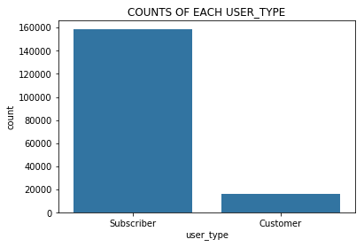

```python
## setting the base color for my charts to avoid multiple colors
base_color = sb.color_palette()[0]
## To arrange my bars in decreasing order
gen_order = bikeshare1['user_type'].value_counts().index
## plotting the bars
sb.countplot(data=bikeshare1, x='user_type', color=base_color, order=gen_order);
plt.title('COUNTS OF EACH USER_TYPE')
```

## (Visualization 2)

Obviously, the number of males were above 120000, while that of females that were involved in bike sharing were not up to half of male. the counts of population that were not male nor female was appproximately 5000.

```
Text(0.5,1,'Proportion of each gender that were involved in bike sharing')
```

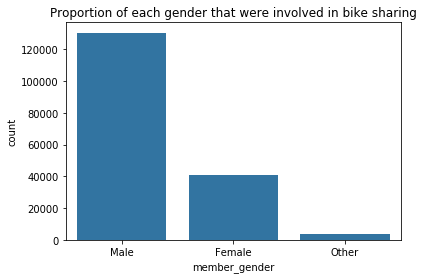

```python
## setting the base color for my charts to avoid multiple colors
base_color = sb.color_palette()[0]
## arranging the bars in decreasing order
gen_order = bikeshare1['member_gender'].value_counts().index
## plotting
sb.countplot(data=bikeshare1, x='member_gender', color=base_color, order=gen_order);
plt.title('Proportion of each gender that were involved in bike sharing')
```

## (Visualization 3)

The histogram is skewed to the right. This might indicate that there was an initial success in the bike sharing scheme as more members were involved. This also indicates that the mean was greater than the median, which is greater than the mode.

```
[61, 10000, 0, 300]
```

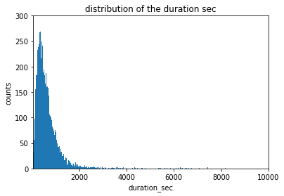

```python
## Setting my bin edges for better view of the chart
bin_edges = np.arange(0, bikeshare1['duration_sec'].max()+1, 1)
## plotting
sb.distplot(bikeshare1['duration_sec'], bins = bin_edges, kde = False, hist_kws = {'alpha' : 1})
plt.title('distribution of the duration sec')
plt.ylabel('counts')
x_min = 61
x_max = 10000
y_min = 0
y_max = 300
plt.axis([x_min, x_max, y_min, y_max])
```

## (Visualization 4)

There are 3 points for male, 3 points for female and one point for others noticed at the top of the duration_sec and just 1 point for female seen at the right corner. This shows that the proprtion of male and female that used the bike for a longer duration were equal, while only a few others rode the bike for that same duration. Interestingly, this chart shows that only one female born in the 1880's used the bike, despite the duration of its use being about 1000secs. It also shows that the number those born in the 1990's and upwards used the bike more often.

```
Text(0.5,1,'Relationship between member_gender, member_birth_year and duration_sec')
```

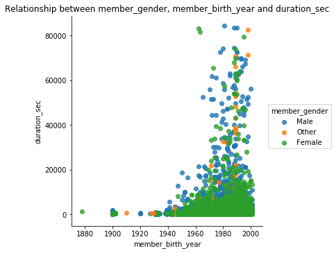

```python
## plotting
sb.lmplot(x='member_birth_year', y='duration_sec', hue='member_gender', data = bikeshare1, fit_reg=False)
plt.title('Relationship between member_gender, member_birth_year and duration_sec')
```

## (Visualization 5)

This chart depicts that customers who fall under other gender used the bike for a longer duration, while the male customers travelled the least distance. This pattern is same for those who subscribed to the scheme.

```
Text(0.5,1,'Relationship between member gender, user type and duration_sec')
```

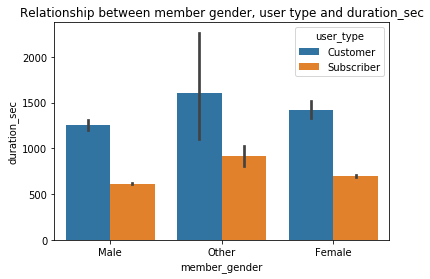

```python
# plotting
sb.barplot(data = bikeshare1, x = 'member_gender', y = 'duration_sec', hue = 'user_type')
plt.title('Relationship between member gender, user type and duration_sec')
```